# Lab 7

Author

Ryan Fernald

Remember, **follow the instructions below and use R Markdown to create a pdf document with your code and answers to the following questions on Gradescope.** You may find a template file by clicking “Code” in the top right corner of this page.

## A. Random sampling in R

1. In your own words, explain the difference between `dnorm()`, `pnorm()`, `qnorm()`, and `rnorm()`.

Each of these is related to the normal distribution, or Gaussian distribution.

dnorm: is used to calculate the probability density function of the Normal Distribution at a given point ‘x’.

it takes x as the point to evaluate the PDF at, mean, for the mean of the normal distribution, and sd for the standard deviation of the normal dist.

pnorm: calculates the cumulative distribution function of the Normal Distribution.

it takes q as the quantile(s) to evaluate the CDF, mean for the mean, sd for the standard deviation, and lower.tail to check random variables less than or equal to q (either TRUE or FALSE).

qnorm: calculates the quantile function which is essentially the inverse of the CDF, cumulative distributive function, for a Normal Distribution.

it takes p, to specify the probability level(s) at which to calculate the quantile, mean and sd as mean and standard deviation.

rnorm: generates random numbers from a normal distribution.

n is the number of random numbers to generate, mean and sd as mean and standard deviation.

2. Suppose we simulate `x <- runif(1)`. What is the distribution of `qnorm(x)`?

we get this:

`-0.3598621`

3. Suppose we simulate `x <- rnorm(1)`. What is the distribution of `pnorm(x)`?

we get this:

`0.1454196`

## B. Gambler’s ruin

A and B are playing a coin flipping game. A starts with $n_a$ pennies and B starts with $n_b$ pennies. A coin is flipped repeatedly and if it comes up heads, B gives A a penny. If it comes up tails, A gives B a penny. The game ends when one player has no more pennies.

4. Write a function `run_one_sim(seed, n_a, n_b)` to simulate one game. Repeatedly use your code with different values of `seed` to estimate each player’s probability of winning when $n_a = n_b = 10$.

Eden helped me with number 4 and 5

```r
library(tidyverse)
```

```r
run_one_sim <- function(seed, n_a, n_b){

   while(n_a > 0 & n_b > 0){
      flips <- sample(x = c("H", "T"),size = 1, replace = T)

       if (flips == "H") {
        n_a <- n_a + 1
        n_b <- n_b - 1
      }
      if (flips == "T") {
        n_a <- n_a - 1
        n_b <- n_b + 1
      }
    }

  return(list(heads = n_a, tails = n_b))
}

a_wins <- 0
b_wins <- 0
runs <- 1000

for(i in 1:runs){
  winCount <- run_one_sim((as.integer(runif(1,min = 1,max = 500))),10,10)

  if(winCount$heads == 0){
    b_wins <- b_wins + 1
  }
  if(winCount$tails == 0){
    a_wins <- a_wins + 1
  }
}

cat("head wins: ", a_wins, '\n')
```

```
head wins:  509
```

```r
cat("tail wins: ", b_wins, '\n\n')
```

```
tail wins:  491
```

```r
if(a_wins > b_wins){
  a_wins/runs
}
```

```
[1] 0.509
```

```r
if(b_wins > a_wins){
  b_wins/runs
}
```

5. Use your function to estimate each player’s probability of winning when $n_a = 1,\ldots, 5$ and $n_b = 1,\ldots, 5$, testing every combination. Organize your results in a 5 by 5 matrix and print it out. What do you notice?

```r
p_matrix <- matrix(0, nrow = 5, ncol = 5)

runs <- 1000

for(i in 1:5){
  #i is representation of n_a, in the i'th row of the matrix
  for(j in 1:5){
    #j is the representation of n_b, in the j'th column in the matrix
    a_win <- 0
    b_win <- 0
    for(k in 1:runs){

      runCount <- run_one_sim((as.integer(runif(1,min = 1,max = 500))),i,j)

      if(runCount$heads == 0){
        b_win <- b_win + 1
      }
      if(runCount$tails == 0){
        a_win <- a_win + 1
      }
    }

    if(a_win > b_win){
      p_matrix[i,j] = a_win/runs
    }
    if(b_win > a_win){
      p_matrix[i,j] =  b_win/runs
    }
  }
}

print(p_matrix)
```

```
      [,1]  [,2]  [,3]  [,4]  [,5]
[1,] 0.503 0.670 0.754 0.810 0.831
[2,] 0.655 0.525 0.603 0.652 0.688
[3,] 0.745 0.595 0.510 0.587 0.608
[4,] 0.776 0.634 0.554 0.515 0.538
[5,] 0.843 0.691 0.630 0.581 0.510
```

The matrix displays the probability of winning with the position on each axis represented by the number of coins each player has. Unsurprisingly on the diagonal, when each competitor has the same number of coins, they have roughly the same chances to win, or 50 - 50. The farther from the center line we deviate the larger the probability that one player will have an advantage to winning.

## C. One-dimensional random walks

In this part, you will simulate a one-dimensional random walk. Suppose you are at the point $x$ at time $t$. At time $t+1$, the probability of moving forwards to $x+1$ is $p$ and the chance of moving backwards to $x-1$ is $1-p$. Assume that at time $t=1$, you are at $x_1=0$.

6. Write a function `random_walk()` that takes as input a numeric `n_steps` and a numeric $p$ and simulates `n_steps` steps of the one-dimensional random walk with forward probability $p$. You may have other input arguments if desired. The output should be a length vector of length `n_steps` starting with 0 where the $i$th entry represents the location of the random walker at time $t=i$. For example, `random_walk(5, .5)` may return the vector $(0, 1, 2, 1, 2)$.

```r
random_walk <- function(n_steps, p) {
  positions <- numeric(n_steps)
  positions[1] <- 0

  for (i in 2:n_steps) {
    random_num <- runif(1)
    if (random_num <= p) {
      positions[i] <- positions[i - 1] + 1
    } else {
      positions[i] <- positions[i - 1] - 1
    }
  }
  return(positions)
}

#set.seed(123)
random_walk(5, 0.5)
```

```
[1] 0 1 0 1 0
```

7. Use your function to generate a random walk of 500 steps with probability $.55$ and generate a line graph with $t=1,\ldots, 500$ on the x-axis and $x_1,\ldots, x_{500}$ on the y-axis.

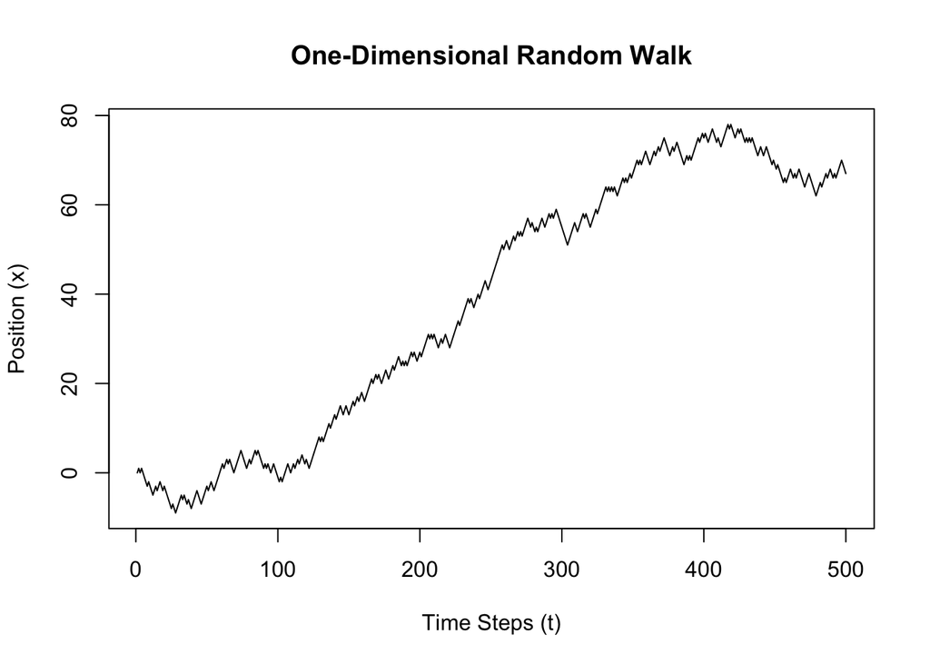

```r
p <- 0.55

plot(1:500, random_walk(500, p), type = "l",
     xlab = "Time Steps (t)", ylab = "Position (x)",
     main = "One-Dimensional Random Walk")
```

8. Use your function to generate two more random walks of 500 steps with probability $p$, where $p\sim \mathrm{Unif}(0, 1)$ and create a line graph with all three of your random walks, using different colors for each walk.

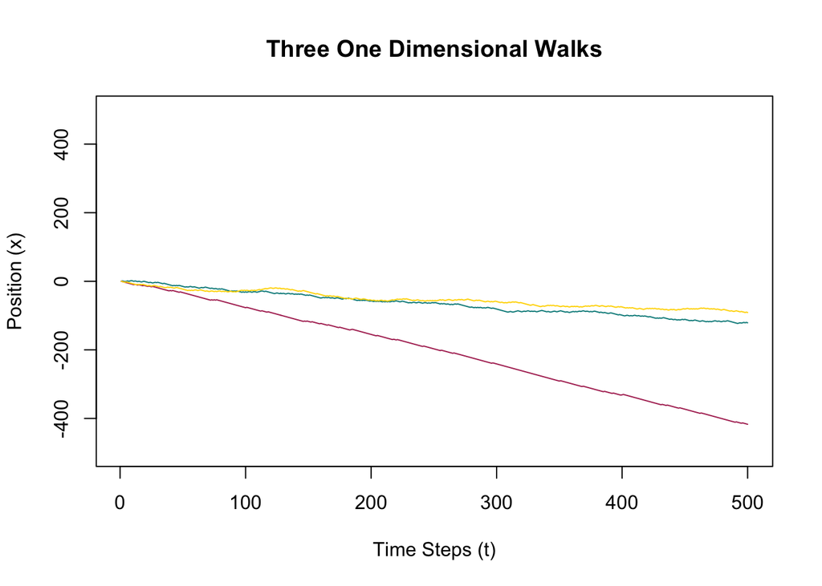

```r
#set.seed(123)
p1 <- runif(1)
p2 <- runif(1)
p3 <- runif(1)

random_walk_1 <- random_walk(500, p1)
random_walk_2 <- random_walk(500, p2)
random_walk_3 <- random_walk(500, p3)

plot(1:500, random_walk_1,
     type = "l",
     col = "darkcyan",
     xlab = "Time Steps (t)",
     ylab = "Position (x)",
     main = "Three One Dimensional Walks",
     ylim = c(-500,500))

lines(1:500, random_walk_2, col = "maroon")
lines(1:500, random_walk_3, col = "gold")
```